# imdbtop1000project(part2)

2023-09-27

````
After running the count Frank Darabont leads the list with a 8.95 rating. The next thing I am going to figure out is which secondary supporting actor('star3' in the dataset), with a minimum of 2 movies, has the most appearances in the dataset.

```r
imdbstar3count <- imdbtop1000v8 %>%
  group_by(star3)%>%
  summarize(number_of_movies = n())

imdbstar3count2 <- imdbstar3count%>%
  filter(number_of_movies >= 2)%>%
  arrange(desc(number_of_movies))

print(imdbstar3count2)
````

```
## # A tibble: 82 × 2
##    star3               number_of_movies
##    <chr>                          <int>
##  1 Rupert Grint                       5
##  2 Carrie Fisher                      4
##  3 Jennifer Connelly                  4
##  4 Joe Pesci                          4
##  5 John Goodman                       4
##  6 Rachel McAdams                     4
##  7 Samuel L. Jackson                  4
##  8 Scarlett Johansson                 4
##  9 Chiwetel Ejiofor                   3
## 10 Christopher Plummer                3
## # ℹ 72 more rows
```

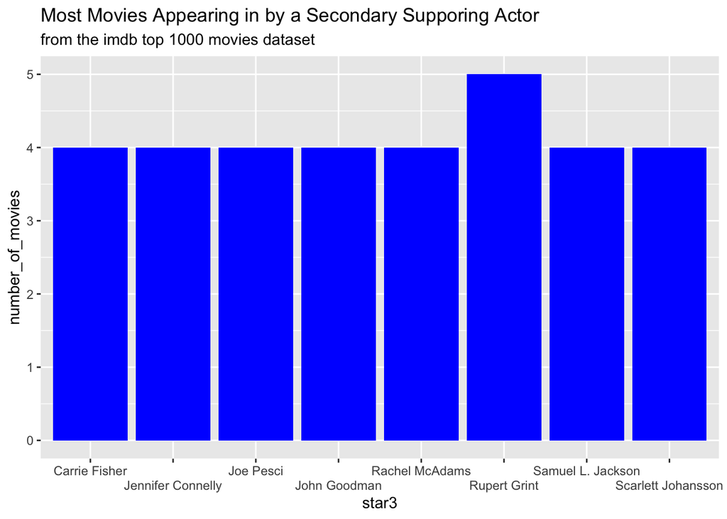

```r
imdbstar3counttop <- imdbstar3count2%>%
  slice_max(number_of_movies, n = 3)

imdbstar3countviz <- ggplot(imdbstar3counttop, aes(star3, number_of_movies))+
  geom_bar(fill = "blue", stat= "identity")+
  theme_classic()%>%
  labs(title = "Most Movies Appearing in by a Secondary Supporing Actor", subtitle = "from the imdb top 1000 movies dataset")+
  scale_x_discrete(guide = guide_axis(n.dodge = 2))

print(imdbstar3countviz)
```

The next thing I would like to do is find the proportion of movies that appear on this list by genre, so first, I need to pull up a count of the genre…

```r
imdbtop1000v8%>%
  count(genre)
```

```
##                             genre  n
## 1               Action, Adventure  5
## 2    Action, Adventure, Biography  1
## 3       Action, Adventure, Comedy 10
## 4        Action, Adventure, Crime  1
## 5        Action, Adventure, Drama 14
## 6       Action, Adventure, Family  1
## 7      Action, Adventure, Fantasy  6
## 8      Action, Adventure, History  1
## 9       Action, Adventure, Horror  1
## 10     Action, Adventure, Mystery  1
## 11     Action, Adventure, Romance  1
## 12      Action, Adventure, Sci-Fi 21
## 13    Action, Adventure, Thriller  5
## 14         Action, Adventure, War  2
```

[output cut: 188 more lines]

After pulling up the count I see that there are 202 genres, this is because the genres in the database are listed first with the main genre, and then further subcategorized with two other genres. In order to better determine the proportion of movies on this list by genre I will create a new column titled ‘main_genre’ and two other columns title ‘alternate_genre1’, ‘alternate_genre2’, I will use the separate function from the dplyr package to do this.

```r
imdbtop1000v9 <- imdbtop1000v8%>%
  separate(genre, into = c("main_genre", "alternate_genre1", "alternate_genre2"), sep = ",")
```

After creating a new column I will now find the proportion of genres that appear in this dataset of top 1000 movies.

First I will determine the count of each ‘main_genre’.

```r
imdbtop1000v9genrecount <- imdbtop1000v9 %>%
  group_by(main_genre)%>%
  summarize(count = n())%>%
  mutate(percent = count/sum(count))

print(imdbtop1000v9genrecount)
```

```
## # A tibble: 14 × 3
##    main_genre count percent
##    <chr>      <int>   <dbl>
##  1 Action       172   0.172
##  2 Adventure     72   0.072
##  3 Animation     82   0.082
##  4 Biography     88   0.088
##  5 Comedy       155   0.155
##  6 Crime        107   0.107
##  7 Drama        289   0.289
##  8 Family         2   0.002
##  9 Fantasy        2   0.002
## 10 Film-Noir      3   0.003
## 11 Horror        11   0.011
## 12 Mystery       12   0.012
## 13 Thriller       1   0.001
## 14 Western        4   0.004
```

Now I will visualize with ggplot…

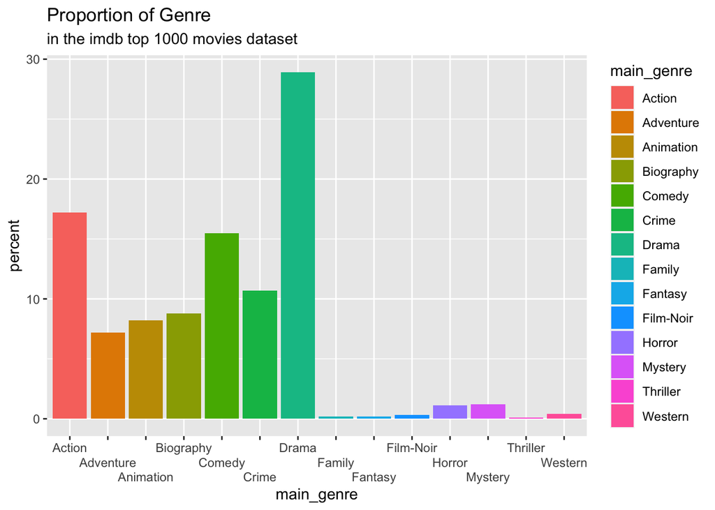

```r
genrecountproportionbar <- ggplot(imdbtop1000v9genrecount, aes(x = factor(main_genre), y = percent * 100, fill = main_genre))+
  geom_bar(stat = "identity")+
  labs(x = "main_genre", y = "percent", title = "Proportion of Genre", subtitle = "in the imdb top 1000 movies dataset")+
  scale_x_discrete(guide = guide_axis(n.dodge = 3))

print(genrecountproportionbar)
```

After visualizing the genre count proportion it’s clear that drama has the highest percentage of close to 30%. This could be visualized with a pie chart, however as shown below, with the amount of genre it’s much easier to visualize with a bar chart.

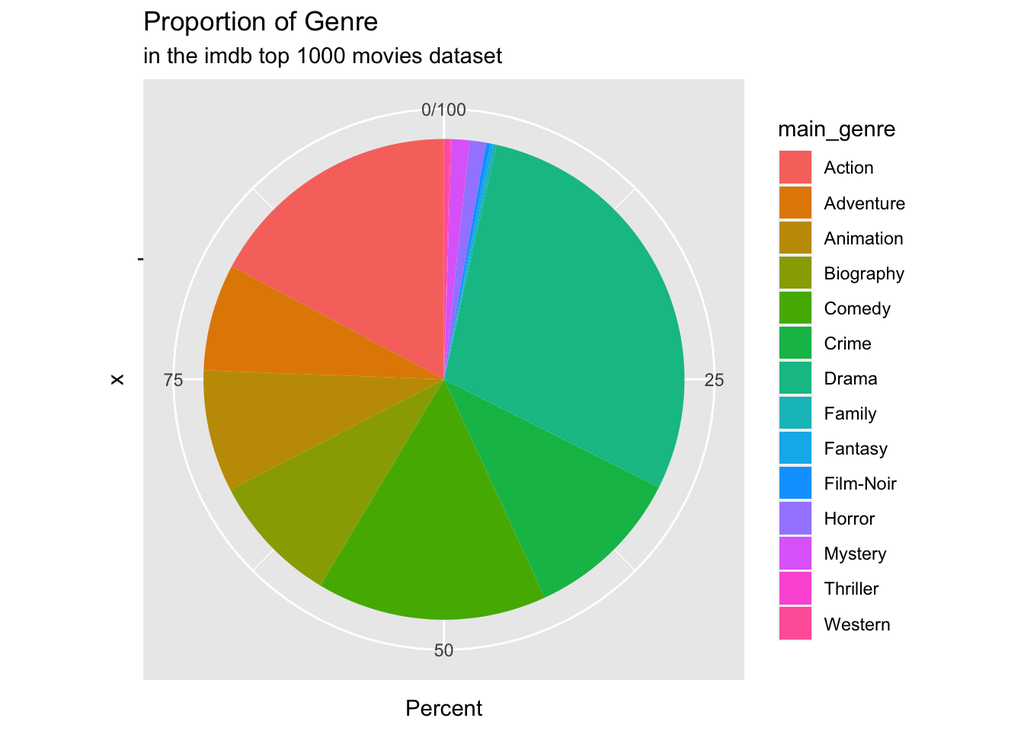

```r
genrecountproportionpie <- ggplot(imdbtop1000v9genrecount, aes(x = "", y = percent * 100, fill = main_genre))+
  geom_col()+
  coord_polar(theta = "y")+
  labs(y = "Percent", title = "Proportion of Genre", subtitle = "in the imdb top 1000 movies dataset")

print(genrecountproportionpie)
```

After finding the proportion of genre in the top 1000 movies dataset, the next I am going to do is find the count of movies on this list in each year.

```r
moviescountbyyear <- imdbtop1000v9 %>%
  group_by(released_year)%>%
  summarize(count = n())

print(moviescountbyyear)
```

```
## # A tibble: 99 × 2
##    released_year count
##    <chr>         <int>
##  1 1920              1
##  2 1921              1
##  3 1922              1
##  4 1924              1
##  5 1925              2
##  6 1926              1
##  7 1927              2
##  8 1928              2
##  9 1930              1
## 10 1931              3
## # ℹ 89 more rows
```

I will now sort it in descending order by count to see which years have the most appearances in this dataset.

```r
moviescountbyyeartop <- moviescountbyyear%>%
  slice_max(count, n = 15)

print(moviescountbyyeartop)
```

```
## # A tibble: 15 × 2
##    released_year count
##    <chr>         <int>
##  1 2014             32
##  2 2004             31
##  3 2009             29
##  4 2013             28
##  5 2016             28
##  6 2001             27
##  7 2006             26
##  8 2007             26
##  9 2015             25
## 10 2012             24
## 11 1993             23
## 12 2010             23
## 13 2019             23
## 14 2003             22
## 15 2017             22
```

After running the count 2014 has the most with 32, one of the things that sticks out is that of the top 15 in the movie count, only 1 comes from before the year 2000.

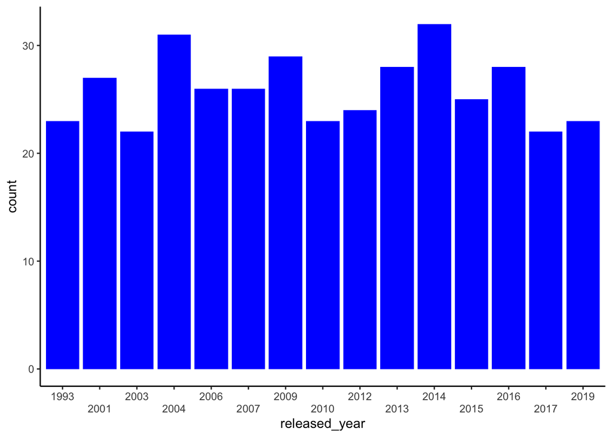

```r
moviescountbyyearviz <- ggplot(moviescountbyyeartop, aes(released_year, count))+
  geom_bar(stat = "identity", fill = "blue" )+
  theme_classic()+
  scale_x_discrete(guide = guide_axis(n.dodge = 2))

print(moviescountbyyearviz)
```

The next thing I am going to find out is what is the average runtime of movies by year in the dataset.

```r
movieruntimebyyear <- imdbtop1000v9 %>%
  group_by(released_year)%>%
  summarize(avg_runtime = mean(runtime))
print(movieruntimebyyear)
```

```
## # A tibble: 99 × 2
##    released_year avg_runtime
##    <chr>               <dbl>
##  1 1920                   NA
##  2 1921                   NA
##  3 1922                   NA
##  4 1924                   NA
##  5 1925                   NA
##  6 1926                   NA
##  7 1927                   NA
##  8 1928                   NA
##  9 1930                   NA
## 10 1931                   NA
## # ℹ 89 more rows
```

After trying to run this, I realize the runtime has ‘min’ also included which could be preventing me from getting the average runtime, so I will isolate the runtime without the ‘min’ portion so I will be able to aggregate the column.

```r
imdbtop1000v10 <- imdbtop1000v9 %>%
  separate(runtime, into = c("runtime", "min"), sep = " ")
```

Now to change the name of the runtime column to indicate that it’s in minutes…

```r
colnames(imdbtop1000v10)[5] = "runtime_minutes"
```

Now I will remove the ‘min’ column since it’s no longer needed…

```r
imdbtop1000v11 <- subset(imdbtop1000v10, select = - 6 )
```

Next I will try to aggregate the new runtime_minutes column to find the average runtime by year for movies in this dataset.

```r
movieruntimebyyear <- imdbtop1000v11 %>%
  group_by(released_year)%>%
  summarize(avg_runtime = mean(runtime_minutes))
```

```r
imdbtop1000v11$runtime_minutes = as.numeric(as.character(imdbtop1000v11$runtime_minutes))

print(sapply(imdbtop1000v11, class))
```

```
##      poster_link     series_title    released_year      certificate
##      "character"      "character"      "character"      "character"
##  runtime_minutes       main_genre alternate_genre1 alternate_genre2
##        "numeric"      "character"      "character"      "character"
##      imdb_rating         overview       meta_score         director
##        "numeric"      "character"        "numeric"      "character"
##            star1            star2            star3            star4
##      "character"      "character"      "character"      "character"
##      no_of_votes            gross           decade
##        "integer"      "character"        "numeric"
```

After seeing that I successfully converted the column to numeric I will now retry to aggregate the runtime_minutes column to find the average runtime by year.

```r
movieruntimebyyear <- imdbtop1000v11 %>%
  group_by(released_year)%>%
  summarize(avg_runtime = round(mean(runtime_minutes),2))
```

I will now sort in descending to find the years with the maximum average runtime….

```r
movieruntimebyyear %>%
  arrange(desc(avg_runtime))
```

```
## # A tibble: 99 × 2
##    released_year avg_runtime
##    <chr>               <dbl>
##  1 1930                 152
##  2 1965                 152.
##  3 1970                 143
##  4 1956                 141.
##  5 1996                 137.
##  6 1959                 137.
##  7 1963                 137
##  8 2012                 136.
##  9 1939                 135
## 10 1966                 133.
## # ℹ 89 more rows
```

I can also visualize this with ggplot…

```
## `geom_line()`: Each group consists of only one observation.
## ℹ Do you need to adjust the group aesthetic?
```

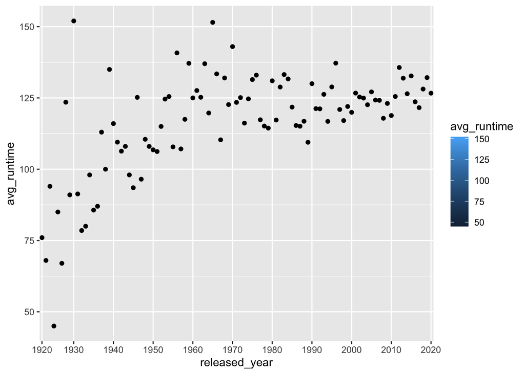

```r
movieruntimebyyearviz <- ggplot(movieruntimebyyear, aes(released_year, avg_runtime))+
  geom_point()+
  geom_line(aes(color = avg_runtime))+
  geom_smooth(method = "lm")+
  scale_x_discrete(breaks = seq(1920, 2030, by = 10))


print(movieruntimebyyearviz)
```

In the visualizion is does appear that the over time the average runtime does seem to increase.

```
Well, that concludes my first data analysis project, over the course of this project I cleaned and validated the data including removing any unnecessary null values, making sure there weren't any duplicates, correcting any grammatical errors and any misspellings.

After cleaning and validating the data, I then began to analyze the data by first finding out what decade has the most movies on this dataset by first creating a new 'decade' column and then sorting and visualizing the movie count. I found out that the decade containing the most movies in this dataset was the 2010's. I then got curious and wanted to find out if i were fo filter for movies with an imdb rating of 8.5 or higher would the movie count be different and indeed it was. The decade containing the most movies of a imdb rating of 8.5 or higher was 1990.

The next thing I wanted to figure out is what was the average imdb rating by decade. After aggregating the imdb_rating column by decade I was able to find out that the average imdb rating was highest (although not by much) in the years 2020 and 1920.

Then, I wanted to find out which primary actor appeared most in the dataset, so I counted the primary actors and then found out that Tom Hanks appears the most with 12 movies. I then did the same with the supporting actor and found out Emma Watson had the most appearances with 7. AFter the supporting actor, I found out which director appeared the most and that was Alfred Hitchcock.

Then, I decided to figure out which director in the dataset had the highest imdb rating average and found that Frank Darabont has the imdb average rating with 8.95. After finding the highest average imdb rating by director, I found out that Rupert Grint has the most appearances on this list amongst secondary supporting actors.
The next thing that I found out is that the largest proportion of genre in this dataset is 'Drama' with an almost 30% proportion. I then found out that 2014 has the most movies in this dataset with 32.

Lastly, I wanted to find out the average runtime by year, in order to do this I first had to rename the 'runtime' column to 'runtime_minutes' and separate the 'min' into a new column and remove it entirely. I Then changed the datatype to numeric and found that from 1920 to about 1970 the average runtime trended upwards and overall the average runtime is higher than it was in the first 50 years in the dataset.
```